# DAISIE Refactor

10-02-2023

## Index

- Overview / status
  - Inference, simulation, plotting
  - Compiled/foreign code (C++, FORTRAN)
  - Dependencies
- Improvements
  - Interface
  - Maintainability
  - Style
- Feedback

## Overview / status

## DAISIE at a glance

```
## [1] "|source |language     | file_count| file_count_pct|   loc|   loc_pct| blank_lines| blank_line_pct| comment_lines| comment_line_pct|"
## [2] "|:------|:------------|----------:|--------------:|-----:|---------:|-----------:|--------------:|-------------:|----------------:|"
## [3] "|DAISIE |R            |        144|      0.4444444| 19894| 0.4382518|        1354|      0.3516883|          5345|        0.4440844|"
## [4] "|DAISIE |HTML         |          4|      0.0123457|  1500| 0.0330440|         140|      0.0363636|             8|        0.0006647|"
## [5] "|DAISIE |C++          |          2|      0.0061728|   440| 0.0096929|         109|      0.0283117|            29|        0.0024094|"
## [6] "|DAISIE |Fortran 95   |          1|      0.0030864|   271| 0.0059700|          76|      0.0197403|           170|        0.0141243|"
## [7] "|DAISIE |C/C++ Header |          3|      0.0092593|   224| 0.0049346|          62|      0.0161039|            11|        0.0009139|"
```

## Inference

- Accessed primarily (but not exclusively) via the `DAISIE_ML_*()` functions
- 5 (6 if redundant `DAISIE_ML()` is counted) functions, common elements in the function tree
- General use of many arguments, defaults prevalent along function trees

## Simulation

- Accessed via the `DAISIE_sim_*()` functions
- 7 (8, if redundant `DAISIE_sim()` is counted) functions, common elements in the function tree

## Plotting

- Accessed via the `DAISIE_plot_*()` functions
- 4 functions, one part of function tree of simulation code

## Acessory functions

- `DAISIE_dataprep()`, `DAISIE_probdist()` etc

## Dependencies

[output not shown]

```
## rsetienne/DAISIE 4.3.0 [new][bld][cmp][dl] (unknown size)
## ├─deSolve 1.34 [new][dl] (2.49 MB)
## ├─DDD 5.0 [new][dl] (871.68 kB)
## │ ├─deSolve
## │ ├─ape 5.6-2 [new][dl] (3.54 MB)
## │ │ ├─nlme 3.1-160 -> 3.1-162 [upd][bld][cmp][dl] (848.55 kB)
## │ │ │ └─lattice 0.20-45
## │ │ ├─lattice
## │ │ └─Rcpp 1.0.10 [new][dl] (2.82 MB)
## │ ├─phytools 1.2-0 [new][dl] (2.27 MB)
## │ │ ├─ape
## │ │ ├─maps 3.4.1 [new][dl] (3.10 MB)
## │ │ ├─clusterGeneration 1.3.7 [new][dl] (268.00 kB)
## │ │ │ └─MASS 7.3-58.1 -> 7.3-58.2 [upd][dl] (1.17 MB)
## │ │ ├─coda 0.19-4 [new][dl] (322.21 kB)
## │ │ │ └─lattice
## │ │ ├─combinat 0.0-8 [new][dl] (42.78 kB)
## │ │ ├─expm 0.999-7 [new][dl] (213.63 kB)
## │ │ │ └─Matrix 1.5-1 -> 1.5-3 [upd][dl] (4.57 MB)
## │ │ │   └─lattice
## │ │ ├─MASS
## │ │ ├─mnormt 2.1.1 [new][dl] (179.98 kB)
## │ │ ├─nlme
## │ │ ├─numDeriv 2016.8-1.1 [new][dl] (116.10 kB)
## │ │ ├─optimParallel 1.0-2 [new][dl] (202.97 kB)
## │ │ ├─phangorn 2.11.1 [new][dl] (2.96 MB)
## │ │ │ ├─ape
## │ │ │ ├─digest 0.6.31 [new][dl] (195.05 kB)
## │ │ │ ├─fastmatch 1.1-3 [new][dl] (39.90 kB)
## │ │ │ ├─generics 0.1.3 [new][dl] (80.51 kB)
## │ │ │ ├─igraph 1.3.5 [new][dl] (5.84 MB)
## │ │ │ │ ├─magrittr 2.0.3 [new][dl] (227.23 kB)
## │ │ │ │ ├─Matrix
## │ │ │ │ ├─pkgconfig 2.0.3 [new][dl] (22.55 kB)
## │ │ │ │ └─rlang 1.0.6 [new][dl] (1.57 MB)
## │ │ │ ├─Matrix
## │ │ │ ├─quadprog 1.5-8 [new][dl] (36.70 kB)
## │ │ │ └─Rcpp
## │ │ ├─plotrix 3.8-2 [new][dl] (1.14 MB)
## │ │ └─scatterplot3d 0.3-42 [new][dl] (352.44 kB)
```

[output cut: 251 more lines]

```
## │ │ ├─jsonlite
## │ │ ├─magrittr
## │ │ ├─rlang
## │ │ ├─tibble
## │ │ └─tidytree
## │ ├─scales
## │ └─cli
## ├─tidytree
## ├─tidyr
## ├─purrr
## ├─ape
## ├─phytools
## └─tibble
##
## Key:  [new] new | [upd] update | [dl] download | [bld] build | [cmp] compile
```

## Dependencies

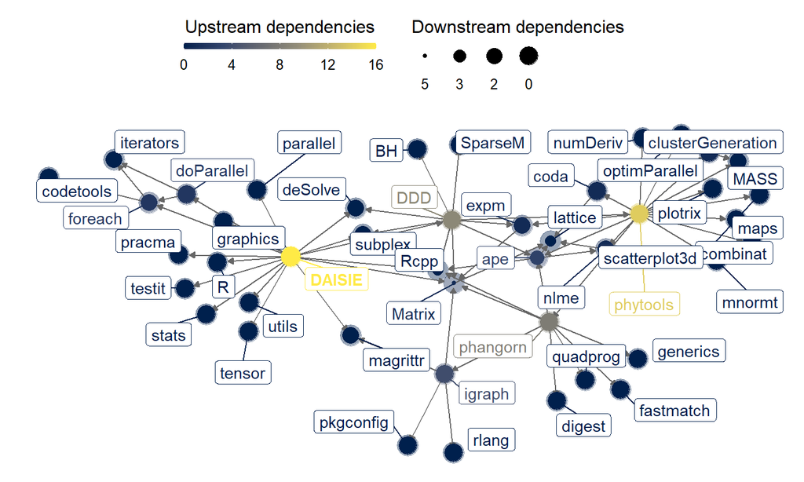

## Dependencies

| generation | n |
| --- | --- |
| -5 | 15 |
| -4 | 19 |
| -3 | 27 |
| -2 | 20 |
| -1 | 17 |
| 0 | 1 |

## Dependencies

- High number of dependencies
- Some package dependencies themselves have a high number of upstream dependencies
- To maintain the package on CRAN, all dependencies on Imports, Depends and Suggests must be equally available
- Critical dependencies include Rcpp, deSolve, DDD (for ML optimization, long term free-standing package?)
- The lower the number of dependencies, higher reliability

## Compiled/foreign code (C++, FORTRAN)

- Numerical integration of ODE system implemented via R, C++ (using BOOST libraries) and FORTRAN code
- Redundant methods are helpful to compare with each other and as fallbacks when one fails
- Increase maintenance cost. Arguably breaks DRY rule.

## Improvements

## Interface

```
DAISIE_sim_cr(
  time,
  M,
  pars,
  replicates,
  divdepmodel = "CS",
  nonoceanic_pars = c(0, 0),
  num_guilds = NULL,
  prop_type2_pool = NA,
  replicates_apply_type2 = TRUE,
  sample_freq = 25,
  plot_sims = TRUE,
  hyper_pars = create_hyper_pars(d = 0, x = 0),
  area_pars = create_area_pars(max_area = 1, current_area = 1, proportional_peak_t = 0,
    total_island_age = 0, sea_level_amplitude = 0, sea_level_frequency = 0,
    island_gradient_angle = 0),
  cond = 0,
  verbose = TRUE,
  ...
)
```

## Interface

- Standardize argument names: choose and rigidly enforce style guide
- Complex arguments should always be named (lists) at the interface level, and as much as possible in inner functions
- Helper functions for complex arguments are an option (e.g., `create_hyper_pars()`)
  - More space for long form documentation, defaults and ease of testing
- Don’t export many currently exported functions

## Maintainability

- Defaults *only* present in user interface
- Deprecate R and FORTAN implementations to a separate package
  - Allows code be kept for tests
  - Same maintenance cost
- Remove dependencies. Consider removing most if not all plotting functions
- Rename ambiguously named functions (i.e., `DAISIE_ML1()`, `DAISIE_ML2()`, etc.)
- Trim down repeated (nearly) identical portions of code (e.g. `DAISIE_ML_*()` functions until `DAISIE_loglik()`)

## Maintainabilty

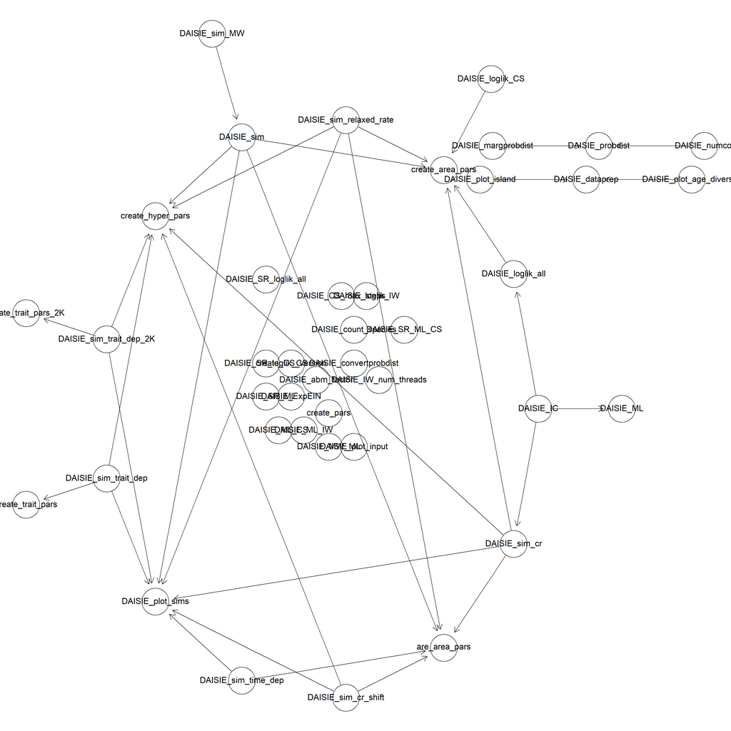

## Feedback

- Thanks for listening! Any comments?